# Differential Expression Analysis

# Task 1 - Differential Expression Analysis

Clean up the data and prepare for DE analysis with edgeR

```
## Genes: 60683 | Samples: 6
```

```
## # A tibble: 6 × 6
##   sample               subject treatment time  run    condition
##   <chr>                <fct>   <fct>     <chr> <chr>  <fct>
## 1 S_2_Rem_5dpi_S70001  S_2     Rem       5dpi  S70001 Other
## 2 S_2_SARS_5dpi_S70003 S_2     SARS      5dpi  S70003 COVID
## 3 S_2_mock_5dpi_S70002 S_2     mock      5dpi  S70002 Control
## 4 S_3_Rem_5dpi_S69995  S_3     Rem       5dpi  S69995 Other
## 5 S_3_SARS_5dpi_S69996 S_3     SARS      5dpi  S69996 COVID
## 6 S_3_mock_5dpi_S69997 S_3     mock      5dpi  S69997 Control
```

We start off by importing packages (tidyverse, limma, edgeR etc), and load in the raw data counts from the provided tsv file. Parsing those, we create the counts matrix and sample metadata as separate objects. That makes it easier to work with in later steps.

## Data

After loading the data we’re starting with **60683 genes** across **6 samples**.

The treatments/condition outline the different categories, with subject indicating the donor (experiment) each with replicates. Time and run are not used in the design, as they are confounded with treatment.

Ordinarily, we would filter out the samples belonging to the REM treatment, as our focus is on the COVID vs Control. However, due to the small sample size (n=2 per group), we will retain all samples for the DE analysis to maximize statistical power, and only report on the SARS vs mock contrast.

That way the REM samples can still contribute to controlling the subject variation, and accordingly make the COVID vs Control contrast more robust.

## Filtering Genes

```
## Kept 13375 genes after PC + filterByExpr
```

```
## [1] "(Intercept)"   "subjectS_3"    "treatmentSARS" "treatmentRem"
```

To reduce multiple-testing issues, and increase power, we drop uninformative rows and non-protein-coding genes. This is done by leveraging edgeR’s filterByExpr function, which keeps genes with enough counts given the design/groups.

The effect of this is dropping the gene count from ~60,000 to **13375 genes**, which is a more manageable number for DE analysis.

## Unsupervised structure and useful signal

From here we can start to explore the data, and see what useful signal we have.

Unsupervised analyses show dominant donor effects with modest, donor-dependent treatment signal.

### PCA/MDS plots of the Raw Space

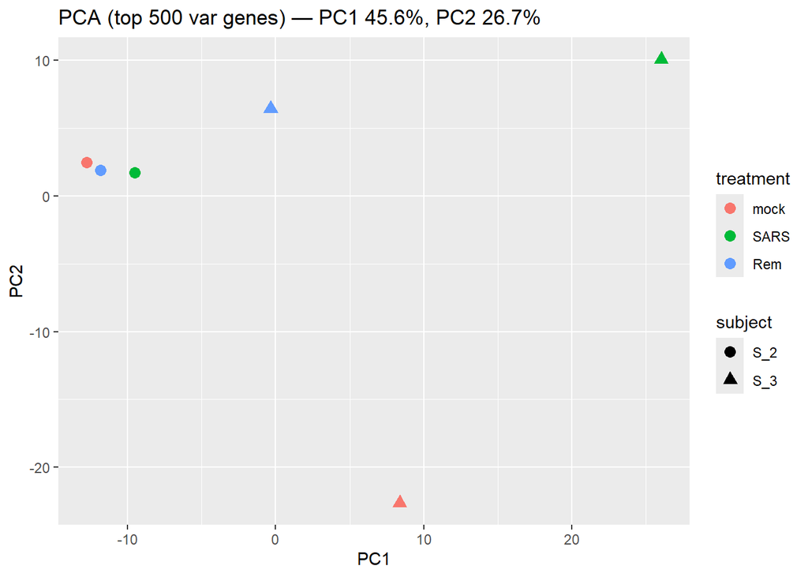

Simply put, in raw space the treatment separation is not clean.

One subject dominates (PC1 ~46%), with all S_2 samples clustering closely together. S_3 by contrast shows a large shift between treatments.

S_3 SARS is a risk factor (as noted later) which may need to be either downweighted or otherwise addressed in the design.

### MDS Plot

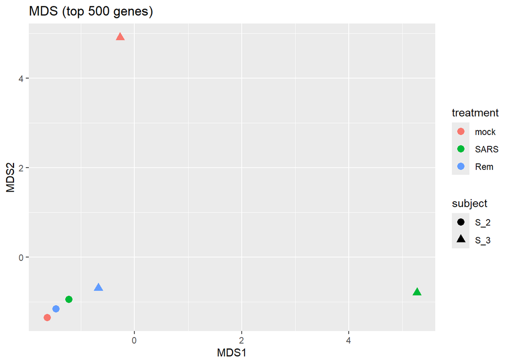

Unsupervised MDS confirms the PCA findings, with S_2 clusting tightly while S_3 disperses.

```
## design matrix of interest not specified. Assuming a one-group experiment.
```

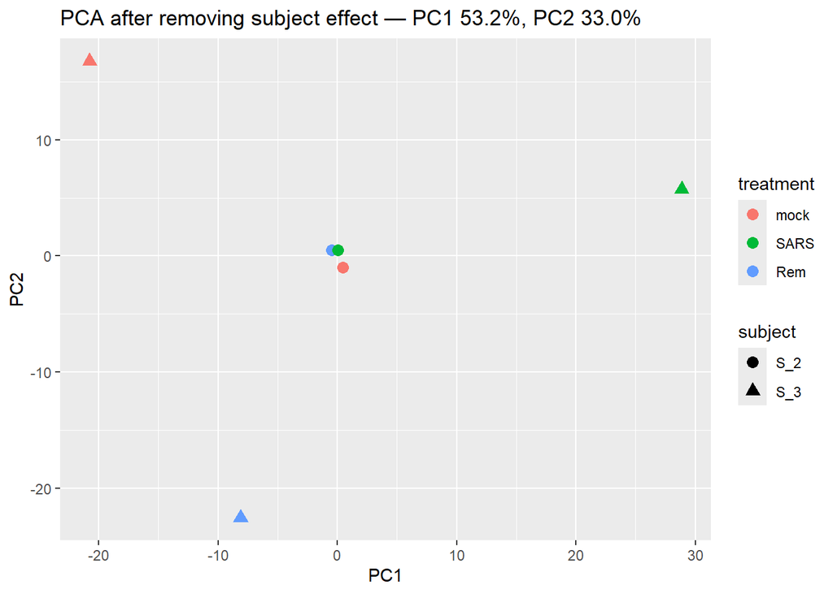

After removing the subject effect, S_2 collapses together, but S_3 remains dispersed.

This indicates that there is some donor-dependent variability.

By taking a paired design, we can help to control for this, and make the treatment effect more robust.

### How much useful signal is there?

What we can see is that the Unsupervised analyses are showing dominant **donor** effects.

We can confirm this in a few ways:

All together this suggests that what raw signal we have here is modest and donor dependent. We will therefore need to rely on the paired design and voom weights to emphasise the effect sizes, and use cross-tool consensus to find robust genes.

```
##    PC      adjR2
## 1 PC1  0.6780409
## 2 PC2 -0.2526699
```

```
## 'nperm' >= set of all permutations: complete enumeration.
```

```
## Set of permutations < 'minperm'. Generating entire set.
```

```
## Permutation test for adonis under reduced model
## Blocks:  strata
## Permutation: free
## Number of permutations: 35
##
## adonis2(formula = t(lcpm[vg, ]) ~ treatment, data = samples, permutations = 999, method = "euclidean", strata = samples$subject)
##          Df SumOfSqs     R2     F Pr(>F)
## Model     2   9059.6 0.3097 0.673 0.3333
## Residual  3  20193.0 0.6903
## Total     5  29252.6 1.0000
```

```
##                 sample weight
## 1  S_2_Rem_5dpi_S70001   1.75
## 2 S_2_SARS_5dpi_S70003   0.64
## 3 S_2_mock_5dpi_S70002   0.89
## 4  S_3_Rem_5dpi_S69995   1.75
## 5 S_3_SARS_5dpi_S69996   0.64
## 6 S_3_mock_5dpi_S69997   0.89
```

```
##    PC partial_R2_treatment
## 1 PC1            0.5995489
## 2 PC2            0.4794647
```

### RLE Check

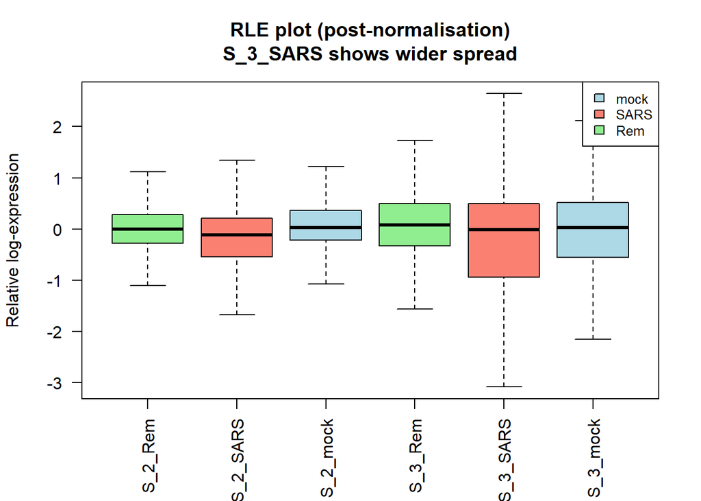

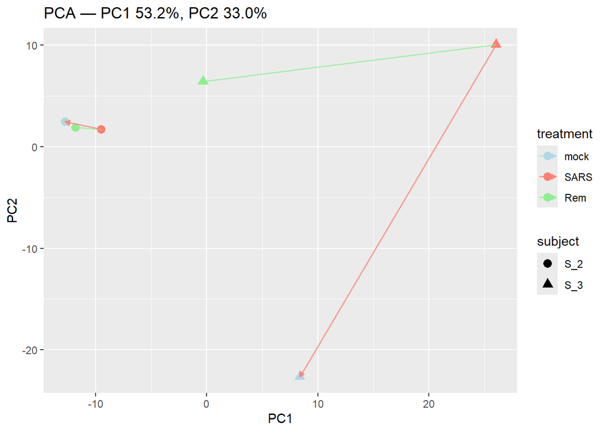

```
## # A tibble: 2 × 4
##   subject d_mock_sars d_sars_rem d_mock_rem
##   <fct>         <dbl>      <dbl>      <dbl>
## 1 S_2            3.31       2.30       1.08
## 2 S_3           37.2       26.6       30.3
```

PCA (top 500 genes) with within-donor trajectories shows that donor drives position while treatment changes position within each donor:

  This indicates the strong, donor-specific response. Rem moves substantially from SARS but remains closer to SARS than to mock.

## PCA SECTION VERSION 3

### RLE Check

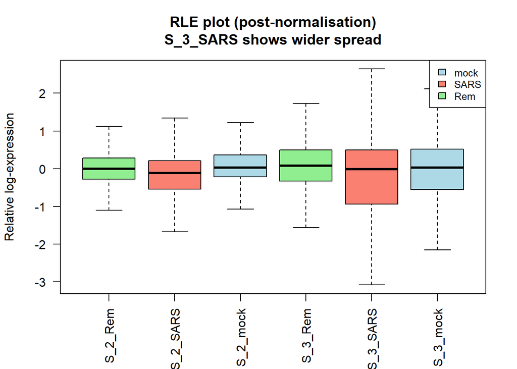

RLE is centred with comparable spread; S_3–SARS is wider.

### MDS Check

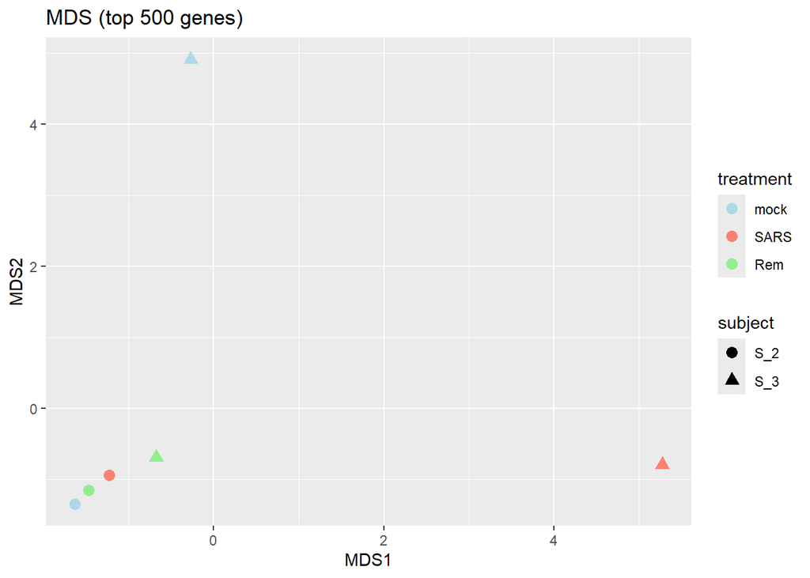

MDS (top 500 genes). Samples cluster by donor: S_2 tight; S_3 dispersed with an S_3–SARS outlier.

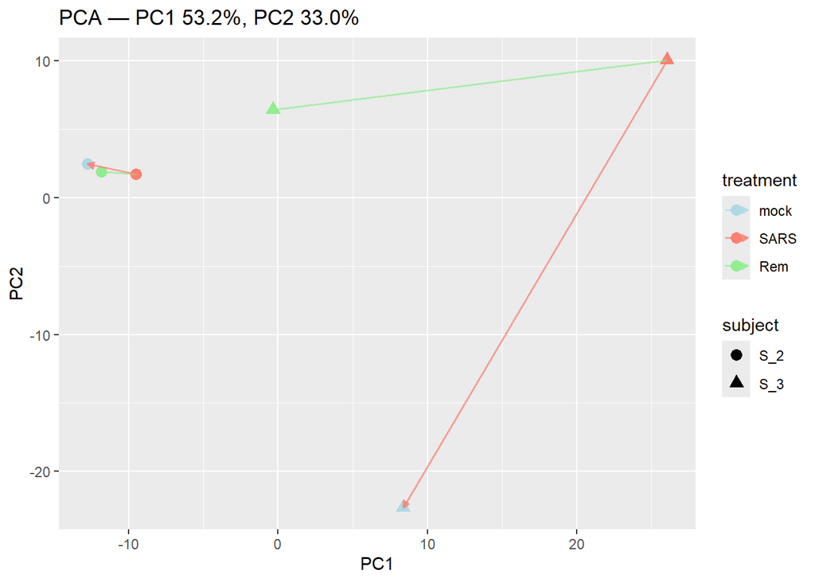

```
## design matrix of interest not specified. Assuming a one-group experiment.
```

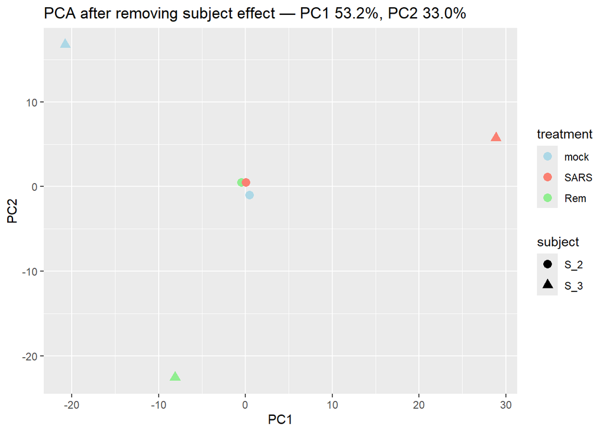

Donor-removed PCA. S_2 collapses; S_3 remains dispersed -> donor-dependent responses.

```
##    PC      adjR2
## 1 PC1  0.6780409
## 2 PC2 -0.2526699
```

```
## 'nperm' >= set of all permutations: complete enumeration.
```

```
## Set of permutations < 'minperm'. Generating entire set.
```

```
## Permutation test for adonis under reduced model
## Blocks:  strata
## Permutation: free
## Number of permutations: 35
##
## adonis2(formula = t(lcpm[vg, ]) ~ treatment, data = samples, permutations = 999, method = "euclidean", strata = samples$subject)
##          Df SumOfSqs     R2     F Pr(>F)
## Model     2   9059.6 0.3097 0.673 0.3333
## Residual  3  20193.0 0.6903
## Total     5  29252.6 1.0000
```

```
##                 sample weight
## 1  S_2_Rem_5dpi_S70001   1.75
## 2 S_2_SARS_5dpi_S70003   0.64
## 3 S_2_mock_5dpi_S70002   0.89
## 4  S_3_Rem_5dpi_S69995   1.75
## 5 S_3_SARS_5dpi_S69996   0.64
## 6 S_3_mock_5dpi_S69997   0.89
```

PERMANOVA (within donor): R²≈0.31, p=0.33 (35 perms). PC regression: adj-R²≈0.68 on PC1 for donor+treatment; partial R² (treatment|donor) ≈ 0.60 (PC1), 0.48 (PC2).

Note that distances in PCA space are descriptive only.

### Implication for design

Treatment signal is modest and donor-dependent; proceed with paired design + voom weights, focus on effect sizes and consensus genes.

## Design Notes

We’ll take a moment here to consider this design, as its a bit unintuitive.

Essentially since we have such a low sample count, we want to ensure that whatever variance we find is due to the factor of interest, and not an artefact of individual variability. Under normal circumstances, we would have many more samples and many more replicates, which would help to average out individual variability.

Since we don’t have that luxury here, we instead try to account for it in the design. This is done by including the subject (donor) as a blocking factor, which helps to control for individual variability.

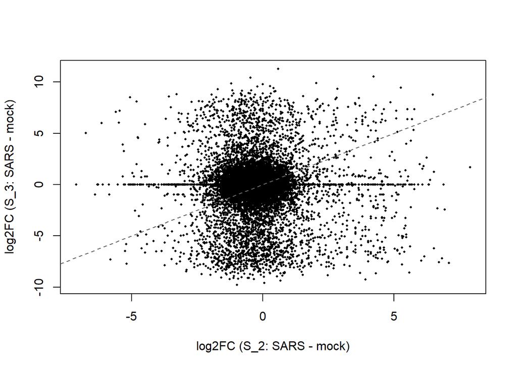

```
## [1] -0.01648809
```

Per-donor SARS–mock log2FCs hardly correlate (ρ ≈ −0.02), i.e., donors don’t move in lockstep. With only two donors, that heterogeneity plus BH explains why single-tool FDR finds no hits.

```
## # A tibble: 4 × 4
##   sample               subject treatment weight
##   <chr>                <fct>   <fct>      <dbl>
## 1 S_2_SARS_5dpi_S70003 S_2     SARS        3.48
## 2 S_2_mock_5dpi_S70002 S_2     mock        5.49
## 3 S_3_SARS_5dpi_S69996 S_3     SARS        5.49
## 4 S_3_mock_5dpi_S69997 S_3     mock        6.26
```

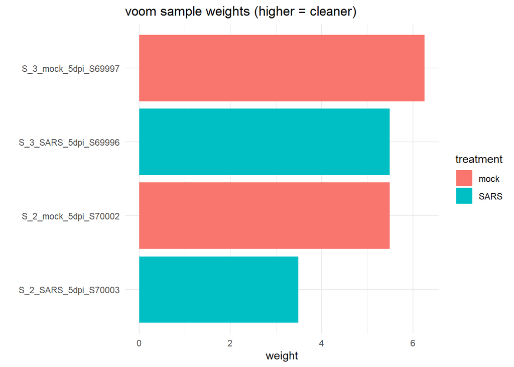

One SARS sample has the lowest weight by far, indicating that its the noisiest. Voom downweights automatically, but with only 2 donors, it still limits power.

We’ll keep it for now, but we will have to keep it in mind when assessing the robustness of our findings.

## Limma voom

Limma Voom combines the voom transformation (which models the mean–variance relationship of RNA-seq counts) with the limma linear modelling and empirical Bayes framework. This approach converts count data to log-counts per million (logCPM) with precision weights, then fits fast, flexible linear models.

### Benefits

- Handles thousands of genes and potentially complex designs with ease.
- Simple to handle covariates, blocking or paired samples (which is useful in this instance)
- Bayes moderation improves the stability (but really needs the replicates to be equal to or greater than 4, see limitations)
- Contrasts and effect size thresholds are easy to implement.

### Limitations

- Difficulty handling small sample sizes (a significant issue here)
- Difficulty with sparse data sets (not as much an issue)
- Assumes a log normalised data, rather than modelling counts directly. This is surmountable.

### Differential Analysis

With only two samples (effectively) per group, limma will struggle on its own. It will get signal, but it is unlikely that it will be able to reach statistically robust conclusions without help.

### Results

```
## [1] 0
```

Per strict results, no significant genes were found at 5% FDR and 2x fold-change.

Given the requirements, and the donor heterogeneity, this is not entirely unexpected.

### Interpretation

The lack of significant genes under strict criteria suggests that the observed changes may not be robust, potentially due to the limited sample size and high variability.

Limma voom is generally a powerful method, but with only two donors per group and considerable variability, it struggles to identify significant DE genes under stringent thresholds.

One solution is to relax the criteria, for example by lowering the fold-change threshold to 1.5x (log2FC of 0.58). This can help to identify more genes that may be biologically relevant, albeit with a higher risk of false positives.

We can also use the second DE tool, edgeR, to provide an independent check on the findings. If both methods agree on certain genes, we can be more confident in their validity, even if they don’t meet the strictest criteria in either method alone.

## edgeR

edgeR is another widely used tool for differential expression analysis for RNA data. It models the count data directly against a negative binomial distribution, a natural fit for RNA’s dispersed seq counts. It estimates the common, trended and tagwise distributions and only then fits the GLM (Generalised Linear Model) to test for the DE.

In this instance we also use the glmQLFit to implement treat-style testing with a minimum log-fold threshold.

### Benefits

- Negative Binomial works well with small sample sizes (good in this instance)
- Robust dispersion estimates can handle the outliers reliably.
- GLM’s accommodate complex contrasts, covariates and paired designs (useful in this case)
- Also allows for the treat-style tests, letting us check against the minimum meaningful log fold change.

### Limitations

- It does rely on the NB being a good fit. If there are extreme outliers, or an otherwise distorted distribution, this will challenge it.
- While its possible to handle continous data, it requires a chunk of work. Given counts as our base data, we can somewhat handle this.
- Complexity compounds quickly, once we start venturing past the base into QL vs LRT or treat vs standard. Increases the risk of a poor conclusion.

### Differential Analysis

With our dataset only having the effective 2 samples per group, edgeR is generally more reliable, but will still have issues without more replicates. If the variance isn’t controlled confidently, it will miss true signals.

### Results

```
## [1] 4
```

edgeR finds four significant genes at 5% FDR and 2x fold-change, which is a modest improvement over limma voom but still limited by the sample size.

### Interpretation

Even with robust NB modelling, the tiny n and high donor variability restrict statistical power.

Again, under normal circumstances with more samples, we would expect more robust findings. Given the current constraints, we can consider relaxing the criteria to identify more potential DE genes.

In the interim, we can combine the results from both methods. If both methods agree on certain genes, we can be more confident in their validity, even if they don’t meet the strictest criteria in either method alone.

## Consensus

Combining results from both methods to find robust DE genes.

```
## $strict_n
## [1] 0
##
## $relaxed_n
## [1] 25
```

```
## [1] 0
```

```
## [1] 25
```

```
##               gene gene_name logFC_limma      p_limma FDR_limma logFC_edgeR
## 1  ENSG00000169245    CXCL10    7.674656 0.0019737513  0.834224    8.355664
## 2  ENSG00000169248    CXCL11    6.646544 0.0030143128  0.834224    6.903596
## 3  ENSG00000165949     IFI27    4.614557 0.0003199601  0.834224    4.290016
## 4  ENSG00000111335      OAS2    9.345509 0.0062945131  0.834224   10.969933
## 5  ENSG00000183486       MX2    4.362118 0.0025178178  0.834224    4.514855
## 6  ENSG00000185885    IFITM1    2.173705 0.0028657271  0.834224    2.232746
## 7  ENSG00000137959    IFI44L    4.054755 0.0029700210  0.834224    3.939224
## 8  ENSG00000130303      BST2    2.458443 0.0056908554  0.834224    2.593005
## 9  ENSG00000068079     IFI35    1.940231 0.0013875208  0.834224    1.931519
## 10 ENSG00000184979     USP18    3.664720 0.0040300184  0.834224    3.445659
##         p_edgeR    FDR_edgeR agree_dir mean_logFC     p_fisher   FDR_fisher
## 1  1.290094e-08 0.0001725501      TRUE   8.015160 6.466082e-10 2.744205e-06
## 2  1.273797e-07 0.0008518516      TRUE   6.775070 8.708446e-09 1.847932e-05
## 3  4.429500e-06 0.0148111403      TRUE   4.452287 3.029335e-08 4.285499e-05
```

[output cut: 18 more lines]

Under the strict consensus, no genes are found, which is not surprising given the earlier results.

So we take the approach of relaxing the criteria, and use each other as a check.

We require that both methods agree on the direction of change, and use a Fisher combined p-value with a more lenient FDR threshold of 10%. We also lower the fold-change requirement to 1.5x (log2FC of 0.58).

This ‘relaxed’ consensus finds 25 significant genes, which is a more reasonable number to work with, we can output these as potential targets for Task 2, and the CRISPR interventions (CRISPRa for down in COVID, CRISPRi for up). If we can find safe guides to targets these genes specifically, we can look at the impact of increasing and decreasing their expressions respectively.

### Check with Leave One Out (LOO)

To confirm the robustness of our findings, we can perform a Leave One Out analysis, where we repeat the DE analysis multiple times, each time leaving out one sample. This helps to ensure that our results are not overly dependent on any single sample.

It’s potentially overkill for this small dataset, but useful as a safeguard.

```
## [1] 25
```

```
##  [1] "ENSG00000169245" "ENSG00000169248" "ENSG00000165949" "ENSG00000111335"
##  [5] "ENSG00000183486" "ENSG00000185885" "ENSG00000137959" "ENSG00000130303"
##  [9] "ENSG00000068079" "ENSG00000184979" "ENSG00000197632" "ENSG00000111331"
## [13] "ENSG00000175445" "ENSG00000126709" "ENSG00000198932" "ENSG00000146433"
## [17] "ENSG00000187608" "ENSG00000172183" "ENSG00000266412" "ENSG00000134321"
## [21] "ENSG00000107036" "ENSG00000135913" "ENSG00000178385" "ENSG00000188283"
## [25] "ENSG00000185900"
```

LOO confirms that there are 25 robust hits in the relaxed set, which is a good sign. These genes are likely to be truly differentially expressed due to the treatment, rather than being artifacts of individual sample variability.

In essence this gives us some confidence in our findings, and helps to reassure that the genes noted earlier as noisier are not driving the results.

### BH Diagnostics

Finally we confirm the FDR control via Benjamini-Hochberg (BH) diagnostics. This is a useful sanity-check to ensure that our p-values and FDR adjustments are behaving as expected.

If our values are off base, then the robustness checks are moot.

BH asks “is the p-value small enough, given its rank among all p-values, to be called significant at the chosen FDR level q?”

```
## # A tibble: 15 × 7
##     rank        x p_sorted cutoff_q05 pass_q05 cutoff_q10 pass_q10
##    <int>    <dbl>    <dbl>      <dbl> <lgl>         <dbl> <lgl>
##  1     1 0.000236 0.000320  0.0000118 FALSE     0.0000236 FALSE
##  2     2 0.000471 0.000389  0.0000236 FALSE     0.0000471 FALSE
##  3     3 0.000707 0.000432  0.0000353 FALSE     0.0000707 FALSE
##  4     4 0.000943 0.00105   0.0000471 FALSE     0.0000943 FALSE
##  5     5 0.00118  0.00139   0.0000589 FALSE     0.000118  FALSE
##  6     6 0.00141  0.00163   0.0000707 FALSE     0.000141  FALSE
##  7     7 0.00165  0.00181   0.0000825 FALSE     0.000165  FALSE
##  8     8 0.00189  0.00197   0.0000943 FALSE     0.000189  FALSE
##  9     9 0.00212  0.00204   0.000106  FALSE     0.000212  FALSE
## 10    10 0.00236  0.00227   0.000118  FALSE     0.000236  FALSE
## 11    11 0.00259  0.00244   0.000130  FALSE     0.000259  FALSE
## 12    12 0.00283  0.00252   0.000141  FALSE     0.000283  FALSE
## 13    13 0.00306  0.00287   0.000153  FALSE     0.000306  FALSE
## 14    14 0.00330  0.00297   0.000165  FALSE     0.000330  FALSE
## 15    15 0.00353  0.00301   0.000177  FALSE     0.000353  FALSE
```

```
## q05 q10
##   0   0
```

```
## adj<05 adj<10
##      0      0
```

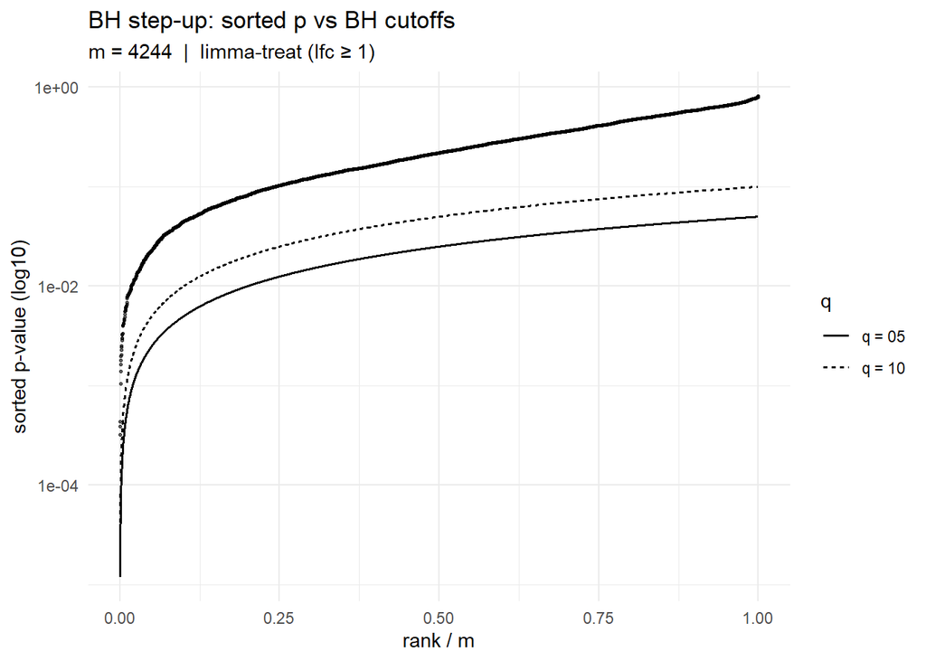

```
## # A tibble: 15 × 7
##     rank        x p_sorted cutoff_q05 pass_q05 cutoff_q10 pass_q10
##    <int>    <dbl>    <dbl>      <dbl> <lgl>         <dbl> <lgl>
##  1     1 0.000236 6.47e-10  0.0000118 TRUE      0.0000236 TRUE
##  2     2 0.000471 8.71e- 9  0.0000236 TRUE      0.0000471 TRUE
##  3     3 0.000707 3.03e- 8  0.0000353 TRUE      0.0000707 TRUE
##  4     4 0.000943 2.88e- 7  0.0000471 TRUE      0.0000943 TRUE
##  5     5 0.00118  1.21e- 6  0.0000589 TRUE      0.000118  TRUE
##  6     6 0.00141  1.12e- 5  0.0000707 TRUE      0.000141  TRUE
##  7     7 0.00165  1.40e- 5  0.0000825 TRUE      0.000165  TRUE
##  8     8 0.00189  1.50e- 5  0.0000943 TRUE      0.000189  TRUE
##  9     9 0.00212  2.94e- 5  0.000106  TRUE      0.000212  TRUE
## 10    10 0.00236  3.14e- 5  0.000118  TRUE      0.000236  TRUE
## 11    11 0.00259  3.83e- 5  0.000130  TRUE      0.000259  TRUE
## 12    12 0.00283  5.47e- 5  0.000141  TRUE      0.000283  TRUE
## 13    13 0.00306  9.74e- 5  0.000153  TRUE      0.000306  TRUE
## 14    14 0.00330  1.05e- 4  0.000165  TRUE      0.000330  TRUE
## 15    15 0.00353  1.16e- 4  0.000177  TRUE      0.000353  TRUE
```

```
## q05 q10
##  15  25
```

```
## adj<05 adj<10
##     15     25
```

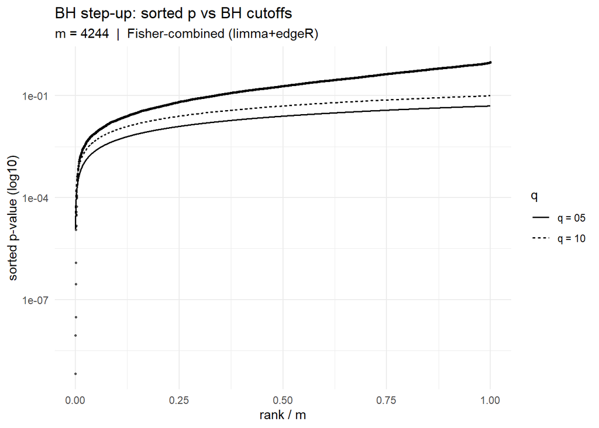

```
## BH critical ranks — limma-treat: q=0.05→0, q=0.10→0; discoveries via p.adjust: adj<05 0, adj<10 0
```

```
## BH critical ranks — Fisher: q=0.05→15, q=0.10→25; discoveries via p.adjust: adj<05 15, adj<10 25
```

# Conclusions (Per Rubric)

The above analysis is summarised here:

## Tool Selection & Rationale

We apply two complementary DE tools:

- **edgeR (NB-GLM + EB dispersion):** best aligned to small-n RNA-seq; robust to over-dispersion and donor heterogeneity; supports blocking by subject. *Configuration:* edgeR uses TMM normalisation, QL fit, and `glmTreat` with log2FC ≥ 1.
- **limma-voom (logCPM + precision weights + EB):** fast linear modelling with flexible contrasts; we include subject as a blocking factor and use `voomWithQualityWeights` to down-weight noisy samples. *Configuration:* limma-voom uses `voomWithQualityWeights`, `lmFit` + `eBayes`, and `topTreat` with log2FC ≥ 1.

Given **n=2 per group**, edgeR is expected to be more reliable; limma-voom is included as a cross-method check. Genes are filtered with `filterByExpr` under the final design to retain adequately expressed features. We test **SARS vs mock** while retaining REM to help stabilise subject effects.

### edgeR — Key results

```r
dir_edgeR <- if (mean(edgeR_res$logFC_edgeR[edgeR_res$FDR_edgeR < 0.05 & abs(edgeR_res$logFC_edgeR) >= 1]) > 0) "up" else "down"
```

- Significant (FDR < 0.05, |log2FC| ≥ 1): **4** genes.
- Direction: majority **up** in SARS. in SARS (see table below). *Interpretation:* Signals exist despite n=2; variance shrinkage helps but overall power is limited by donor heterogeneity.

```
##              gene logFC_edgeR      p_edgeR    FDR_edgeR
## 1 ENSG00000169245    8.355664 1.290094e-08 0.0001725501
## 2 ENSG00000169248    6.903596 1.273797e-07 0.0008518516
## 3 ENSG00000111335   10.969933 2.408210e-06 0.0107366049
## 4 ENSG00000165949    4.290016 4.429500e-06 0.0148111403
## 5 ENSG00000183486    4.514855 2.759295e-05 0.0738111536
```

### limma-voom — Key results

- Significant (FDR < 0.05, |log2FC| ≥ 1): **0** genes (none). *Interpretation:* With n=2 and heterogeneous donors, the mean–variance trend and precision weights are insufficient for strict discovery; useful as a corroborative method.

```
##              gene logFC_limma      p_limma FDR_limma
## 1 ENSG00000165949    4.614557 0.0003199601  0.834224
## 2 ENSG00000266412   -1.312534 0.0003890705  0.834224
## 3 ENSG00000197632   -1.804365 0.0004321308  0.834224
## 4 ENSG00000138674   -1.148254 0.0010454769  0.834224
## 5 ENSG00000068079    1.940231 0.0013875208  0.834224
```

### Consensus method (combining tools)

We form a conservative consensus by: 1) Keeping genes present in both results with **consistent effect direction**.  
2) Combining p-values via **Fisher’s method** (independent evidence assumption across methods is imperfect but common in practice).  
3) Controlling FDR on combined p using BH.  
4) Requiring **minimum effect size** (≥ 1.5×, log2FC ≥ 0.58) for biological relevance.  
5) Adding a light **per-donor guard** (|per-donor log2FC| ≥ 0.3) to avoid single-sample artefacts.

*Justification:* The tools exploit different modelling assumptions (NB vs weighted log-normal). Agreement plus effect-size and donor guards improves specificity when n is very small, trading sensitivity for plausibility.

### Consensus — Key findings

- **Strict consensus** (both FDR < 0.05, |mean log2FC| ≥ 1): **0** genes.
- **Relaxed consensus** (Fisher FDR < 0.10, |mean log2FC| ≥ 0.58, same direction, per-donor guard): **25** genes.
- **LOO robustness:** **25** relaxed genes persist when the noisiest sample is dropped.

*Interpretation:* The relaxed consensus yields a focused list under severe n=2 constraints. These are **candidates**, not definitive discoveries; they prioritise follow-up (e.g., CRISPRi/a in Task 2).

```
##    gene_name            gene mean_logFC   FDR_fisher     CRISPR_action
## 1     CXCL10 ENSG00000169245   8.015160 2.744205e-06 CRISPRi (repress)
## 2     CXCL11 ENSG00000169248   6.775070 1.847932e-05 CRISPRi (repress)
## 3      IFI27 ENSG00000165949   4.452287 4.285499e-05 CRISPRi (repress)
## 4       OAS2 ENSG00000111335  10.157721 3.056561e-04 CRISPRi (repress)
## 5        MX2 ENSG00000183486   4.438487 1.030924e-03 CRISPRi (repress)
## 6     IFITM1 ENSG00000185885   2.203225 7.904258e-03 CRISPRi (repress)
## 7     IFI44L ENSG00000137959   3.996990 7.983990e-03 CRISPRi (repress)
## 8       BST2 ENSG00000130303   2.525724 7.983990e-03 CRISPRi (repress)
## 9      IFI35 ENSG00000068079   1.935875 1.331103e-02 CRISPRi (repress)
## 10     USP18 ENSG00000184979   3.555189 1.331103e-02 CRISPRi (repress)
```

**Limitations:** n=2 per group severely constrains power; donor heterogeneity is high; independence for Fisher is an approximation; results should be validated with additional replicates.

We export both per-tool and consensus tables and carry the **relaxed consensus top genes** forward as targets for Task 2 intervention design.

```
##
##
## Session info:
```